# Introduction to R

To perform data analysis in Psychology, one needs some powerful software to help you get data into shape, and to apply all the fancy statistical tests that you will learn about in this course. In this course, we will be using the programming language R and the software R Studio to do this.

### **Quick Links**

1. Packages
2. Conflicts
3. Datatypes

### **R and R Studio**

For this course, you need two different bits of software, [R](https://www.r-project.org/) and [RStudio](https://www.rstudio.com/products/rstudio/download/#download). R is a programming language that you will write code in aCnd R Studio is an Integrated Development Environment (IDE) which makes working with R easier. Think of it as knowing English and using a plain text editor like NotePad to write a book versus using a word processor like Microsoft Word. You could do it, but it wouldn’t look as good and it would be much harder without things like spell-checking and formatting. In a similar way, you can use R without R Studio but we wouldn’t recommend it. The key thing to remember is that although you will do all of your work using R Studio for this course, you are actually using two pieces of software which means that from time-to-time, both of them may have separate updates.

R is a free and open-source programming language that is widely used for statistical computing and data analysis. R Studio is a user-friendly interface that makes it easier to write and run R code, manage files, and visualize data.

All of the School of Psychology computers have R and R Studio installed, however, we can only guarantee that the computers in the Level 2 psychology labs have the right set-up.

Both R and RStudio are freely available so you may wish to install them on your own machine. There is a useful [guide to installing them both here](https://psyteachr.github.io/hack-your-data/r_instructions.html) that you can use. Note that the PSYC2001 staff are unable to help you if you have specific technical issues setting up R and RStudio on your own machine. But the tutors can support you using R and RStudio on the School of Psychology computers in the computer labs. If you are having specific technical issues setting this up on your own machine, then you should submit an issue to UNSW IT Services.

### **Getting to know R Studio**

R Studio has a console that you can try out code in (appearing as the bottom left window in **Figure 1**, there is a script editor (top left), a window showing functions and objects you have created in the “Environment” tab (top right window in the figure), and a window that shows plots, files packages, and help documentation (bottom right).

[figure not shown]

Figure 1: RStudio interface

### **Functions and arguments**

**Functions** in R allow you to perform tasks that would take a long time to write out by hand, by only using one term! Think of them as nifty tools that will save you lots of typing, again and again. A function normally takes a number of **arguments** (you might want to think as these as verbs that require a subject and an object). You can look up all the arguments that a function takes by using the help documentation by using the format `?function`. Some arguments are required, and some are optional. Optional arguments will often use a default (normally specified in the help documentation) if you do not enter any value.

As an example, let’s look at the help documentation for the function `rnorm()` which randomly generates a set of numbers with a normal distribution.

### **Activity 1**

Open up R Studio and in the console, type the following code:

```r
?rnorm
```

The help documentation for `rnorm()` should appear in the bottom right help panel. We know that the documentation for rnorm can be a little bit… confusing. To simplify the `rnorm()` function is used to simulate data points from a normal distribution with a given mean and standard deviation. Do not worry about pnorm/dnorm, they can remain as mythical functions in the interest of simplicity.

In the usage section, we see that `rnorm()` takes the following form:

```r
rnorm(n, mean = 0, sd = 1)
```

In the arguments section, there are explanations for each of the arguments. `n` is the number of observations we want to create, `mean` is the mean of the data points we will create and `sd` is the standard deviation of the set. In the details section it notes that if no values are entered for `mean` and `sd` it will use a default of 0 and 1 for these values. Because there is no default value for `n` it must be specified otherwise the code won’t run.

Let’s try an example and just change the required argument `n` to ask R to produce 5 random numbers.

### **Activity 2**

- Copy and paste the following code into the console.

```r
set.seed(12042016)
rnorm(n = 5)
```

```
## [1] -0.2896163 -0.6428964  0.5829221 -0.3286728 -0.5110101
```

These numbers have a mean of 0 and an SD of 1. Now we can change the additional arguments to produce a different set of numbers.

```r
rnorm(n = 5, mean = 10, sd = 2)
```

```
## [1] 13.320853  9.377956 10.235461  9.811793 13.019102
```

This time R has still produced 5 random numbers, but now this set of numbers has a mean of 10 and an sd of 2 as specified. Always remember to use the help documentation to help you understand what arguments a function requires.

### **Argument names**

In the above examples, we have written out the argument names in our code (e.g., `n`, `mean`, `sd`), however, this is not strictly necessary. The following two lines of code would both produce the same result (although each time you run `rnorm()` it will produce a slightly different set of numbers, because it’s random, but they would still have the same mean and SD):

```r
rnorm(n = 6, mean = 3, sd = 1)
rnorm(6, 3, 1)
```

Importantly, if you do not write out the argument names, R will use the default order of arguments, that is for `rnorm` it will assume that the first number you enter is `n`. the second number is `mean` and the third number is `sd`.

If you write out the argument names then you can write the arguments in whatever order you like:

```r
rnorm(sd = 1, n = 6, mean = 3)
```

When you are first learning R, you may find it useful to write out the argument names as it can help you remember and understand what each part of the function is doing. However, as your skills progress you may find it quicker to omit the argument names and you will also see examples of code online that do not use argument names so it is important to be able to understand which argument each bit of code is referring to (or look up the help documentation to check).

In this course, we will always write out the argument names the first time we use each function, however, in subsequent uses they may be omitted.

### **Tab auto-complete**

One very useful feature of R Studio is the tab auto-complete for functions (**see Figure 2: Tab auto-complete**). If you write the name of the function and then press the tab key, R Studio will show you the arguments that function takes along with a brief description. If you press enter on the argument name it will fill in the name for you, just like auto-complete on your phone. This is incredibly useful when you are first learning R and you should remember to use this feature frequently.

[figure not shown]

Figure 2: Tab auto-complete

### **Base R and packages**

When you install R you will have access to a range of functions including options for data wrangling and statistical analysis. The functions that are included in the default installation are typically referred to as **Base R** and there is a useful cheat sheet that shows many Base R functions [here](https://stat.ethz.ch/R-manual/R-devel/library/base/html/00Index.html).

However, the power of R is that it is extendable and open source - put simply, if a function doesn’t exist or doesn’t work very well, anyone can create a new **package** that contains data and code to allow you to perform new tasks. You may find it useful to think of Base R as the default apps that come on your phone and packages as additional apps that you need to download separately.

### Installing and loading packages

**Info:** The UNSW psychology computers will already have all of the packages you need for this course so you only need to install packages if you are using your own machine. **Please do not install any packages on the university machines.**

### **Activity 3: Install the tidyverse**

In order to use a package, you must first install it. The following code installs the package `tidyverse`, a package we will use very frequently in this course.

If you are interested in learning more about tidyverse and how incredibly useful it is in R, please consider reading [R for Data Science](https://r4ds.hadley.nz/)

- If you are working on your own computer, use the below code to install the tidyverse. **Do not do this if you are working on a University machine**.

```r
install.packages("tidyverse")
```

You only need to install a package once, however, each time you start R you need to load the packages you want to use, in a similar way that you need to install an app on your phone once, but you need to open it every time you want to use it.

To load packages we use the function `library()`. Typically you would start any analysis script by loading all of the packages you need, but we will come back to that in the labs.

### **Activity 4: Load the tidyverse**

- Run the below code to load the tidyverse. You can do this regardless of whether you are using your own computer or a University machine.

```r
library(tidyverse)
```

You will get what looks like an error message - it’s not. It’s just R telling you what it’s done.

Now that we’ve loaded the `tidyverse` package we can use any of the functions it contains but remember, you need to run the `library()` function every time you start R.

### **Package updates**

In addition to updates to R and R Studio, the creators of packages also sometimes update their code. This can be to add functions to a package, or it can be to fix errors. One thing to avoid is unintentionally updating an installed package. When you run `install.packages()` it will always install the latest version of the package and it will overwrite any older versions you may have installed. Sometimes this isn’t a problem, however, sometimes you will find that the update means your code no longer works as the package has changed substantially. It is possible to revert back to an older version of a package but try to avoid this anyway.

**Warning:** To avoid accidentally overwriting a package with a later version, you should **never** include `install.packages()` in your analysis scripts in case you, or someone else runs the code by mistake. Remember, the UNSW psychology computers will already have all of the packages you need for this course so you only need to install packages if you are using your own machine.

### **Package conflicts**

There are thousands of different R packages with even more functions. Unfortunately, sometimes different packages have the same function names. For example, the packages `dplyr` and `MASS` both have a function named `select()`. If you load both of these packages, R will produce a warning telling you that there is a conflict.

```r
library(dplyr)
library(MASS)
```

If you want to specify which package you want to use for a particular function you can use code in the format `package::function`, for example:

```r
dplyr::select()
MASS::select()
```

## Note that this is for your own information, so that you aren’t alarmed when you see such messages in your great future of data analysis. You won’t have to worry about package conflicts during this course.

### **Objects**

A large part of your coding for data analysis will involve creating and manipulating objects. Objects contain stuff. That stuff can be numbers, words, or the result of operations and analyses.You assign content to an object using `<-`.

### **Activity 5: Create some objects**

- Copy and paste the following code into the console, change the code so that it uses your own name and age and run it. You should see that `name`, `age`, `today`, `new_year`, and `data` appear in the environment pane.

```r
name <- "emily"
age <- 15 + 18
today <-Sys.Date()
new_year <- as.Date("2020-01-01")
data <- rnorm(n = 10, mean = 15, sd = 3)
```

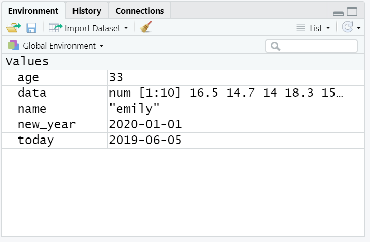

Figure 3: Objects in the environment

Note that in these examples, `name`,`age`, and `new_year` would always contain the values `emily`, `33`, and the date of New Year’s Day 2020, however, `today` will draw the date from the operating system and `data` will be a randomly generated set of data so the values of these objects will not be static.

**Info:** You may also see objects referred to as ‘variables’. There is a difference between the two in programming terms, however, they are used synonymously very frequently.

As a side note, if you ever have to teach programming and statistics, don’t use your age as an example because everytime you have to update your teaching materials you get a reminder of the fragility of existence and your advancing age.

Importantly, objects can be involved in calculations and can interact with each other. For example:

```r
age + 10
```

```
## [1] 43
```

```r
new_year - today
```

```
## Time difference of -2066 days
```

```r
mean(data)
```

```
## [1] 17.66644
```

Finally, you can store the result of these operations in a new object:

```r
decade <- age + 10
```

**Tip:** You may find it helpful to read `<-` as `contains`, e.g., `name` contains the text `emily`.

### **Datatypes**

You will constantly be creating objects throughout this course and you will learn more about them and how they behave as we go along, however, for now it is enough to understand that they are a way of saving values, that these values can be numbers, text, or the result of operations, and that they can be used in further operations to create new variables. For now, we can have a look at the datatypes of our objects using the function `typeof`.

```r
#These are both doubles (i.e numbers!)
typeof(age)
```

```
## [1] "double"
```

```r
typeof(new_year)
```

```
## [1] "double"
```

```r
#This is a chr (i.e contains letters!)
typeof(name)
```

```
## [1] "character"
```

**Info:** There are 5 main datatypes: double, integer, complex, logical and character. For historic reasons, double is also called numeric. We will learn about and use many of these different datatypes in this course.

We will learn about using these datatypes (as well as some of the others) throughout this course, so don’t fret if you don’t understand it yet !

### **Looking after the environment**

If you’ve been writing a lot of code you may find that the environment pane (or workspace) has become cluttered with many objects. This can make it difficult to figure out which object you need and therefore you run the risk of using the wrong data frame. If you’re working on a new dataset, or if you’ve tried lots of different code before getting the final version, it is good practice to remember to clear the environment to avoid using the wrong object. You can do this in several way.

1. To remove individual objects, you can type `rm(object_name)` in the console. Try this now to remove one of the objects you created in the previous section.
2. To clear all objects from the environment run `rm(list = ls())` in the console.
3. To clear all objects from the environment you can also click the broom icon in the environment pane.

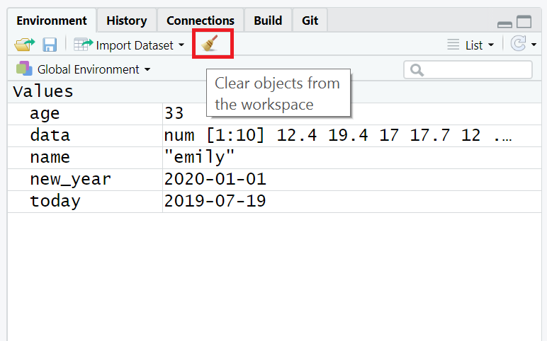

Figure 4: Clearing the workspace

### **You are Free!**

Congratulations you have survived the first tutorial for this course. We look forward to seeing you next week for more coding fun.

[figure not shown]

Figure 5: Students reaction to finishing this